# ETL PNAD

[figure not shown]

# O que é PNAD?

A Pesquisa Nacional por Amostra de Domicílios (PNAD) era uma pesquisa anual realizada pelo IBGE nos domicílios brasileiros para apurar características gerais da população, incluindo dados de educação, trabalho, rendimento e habitação, além de levantar, com periodicidade variável, outros temas, de acordo com as necessidades de informação para o país.

A pesquisa foi encerrada em 2016 e substituída, com metodologia atualizada, pela Pesquisa Nacional por Amostra de Domicílios Contínua – PNAD Contínua.

## Resumo

Será feita uma análise do conjunto de dados da PNAD de 2012, a fim de extrair informações relevantes

# Visão geral do conjunto de dados

```r
df %>% str
```

```
## spec_tbl_df[,9] [362,451 × 9] (S3: spec_tbl_df/tbl_df/tbl/data.frame)
##  $ Ano                 : num [1:362451] 2012 2012 2012 2012 2012 ...
##  $ Estado              : chr [1:362451] "Rondônia" "Rondônia" "Rondônia" "Rondônia" ...
##  $ Sexo                : chr [1:362451] "Masculino" "Feminino" "Feminino" "Feminino" ...
##  $ Idade               : num [1:362451] 48 48 23 21 54 56 23 63 39 49 ...
##  $ Cor da pele         : chr [1:362451] "Branca" "Branca" "Branca" "Branca" ...
##  $ Anos de escolaridade: chr [1:362451] "15 anos ou mais" "15 anos ou mais" "15 anos ou mais" "14 anos" ...
##  $ Renda principal     : num [1:362451] 3000 3000 1100 1100 NA 10000 500 NA 622 1200 ...
##  $ Renda total         : num [1:362451] 3000 3000 1100 1100 460 10000 500 622 622 1200 ...
##  $ Peso amostral       : num [1:362451] 232 232 232 232 232 232 233 233 233 232 ...
##  - attr(*, "spec")=
##   .. cols(
##   ..   V0101 = col_double(),
##   ..   UF = col_character(),
##   ..   V0302 = col_character(),
##   ..   V8005 = col_double(),
##   ..   V0404 = col_character(),
##   ..   V4803 = col_character(),
##   ..   V4718 = col_character(),
##   ..   V4720 = col_character(),
##   ..   V4729 = col_double()
##   .. )
```

```r
df %>% head %>% knitr::kable()
```

| Ano | Estado | Sexo | Idade | Cor da pele | Anos de escolaridade | Renda principal | Renda total | Peso amostral |
| --- | --- | --- | --- | --- | --- | --- | --- | --- |
| 2012 | Rondônia | Masculino | 48 | Branca | 15 anos ou mais | 3000 | 3000 | 232 |
| 2012 | Rondônia | Feminino | 48 | Branca | 15 anos ou mais | 3000 | 3000 | 232 |
| 2012 | Rondônia | Feminino | 23 | Branca | 15 anos ou mais | 1100 | 1100 | 232 |
| 2012 | Rondônia | Feminino | 21 | Branca | 14 anos | 1100 | 1100 | 232 |
| 2012 | Rondônia | Feminino | 54 | Branca | 15 anos ou mais | NA | 460 | 232 |
| 2012 | Rondônia | Masculino | 56 | Preta | 15 anos ou mais | 10000 | 10000 | 232 |

# Verificando dados nulos

```r
colSums(is.na(df)) %>% knitr::kable()
```

|  | x |
| --- | --- |
| Ano | 0 |
| Estado | 0 |
| Sexo | 0 |
| Idade | 0 |
| Cor da pele | 0 |
| Anos de escolaridade | 0 |
| Renda principal | 193470 |
| Renda total | 58817 |
| Peso amostral | 0 |

# Distribuição da pesquisa por cor da pele

```r
distCor <- ((df$`Cor da pele` %>% table() / nrow(df)) * 100 ) %>%  as.tibble() %>% arrange(desc(n))
colnames(distCor) <- c("Cor da pele","Distribuicao"); distCor$Distribuicao <- round(distCor$Distribuicao, 2)
distCor$Distribuicao <- str_c(distCor$Distribuicao %>% as.character(),"%")
distCor %>% knitr::kable()
```

| Cor da pele | Distribuicao |
| --- | --- |
| Parda | 47.93% |
| Branca | 42.93% |
| Preta | 8.31% |
| Amarela | 0.43% |
| Indígena | 0.4% |
| Sem declaração | 0% |

**OBS:** A maioria das pessoas pesquisadas são pardas e brancas

# Distribuição da pesquisa por sexo

```r
distSexo <- ((df$Sexo %>% table / nrow(df)) * 100) %>% as.tibble()
colnames(distSexo) <- c("Sexo","Distribuicao"); distSexo$Distribuicao <- str_c(round(distSexo$Distribuicao,2),"%")
distSexo %>% knitr::kable()
```

| Sexo | Distribuicao |
| --- | --- |
| Feminino | 51.33% |
| Masculino | 48.67% |

# Media de idade dos participantes

```r
dfFeminino <- df %>% filter(Sexo=="Feminino") %>% na.omit
dfMasculino <- df %>% filter(Sexo=="Masculino") %>% na.omit

tibble("Media de idade Mulheres"=dfFeminino$Idade %>% mean, "Media de idade Homens"=dfMasculino$Idade %>% mean, "Media idade Geral"=df$Idade %>% mean) %>% knitr::kable()
```

| Media de idade Mulheres | Media de idade Homens | Media idade Geral |
| --- | --- | --- |
| 37.80578 | 37.95343 | 32.63801 |

# Analisando renda dos participantes por idade

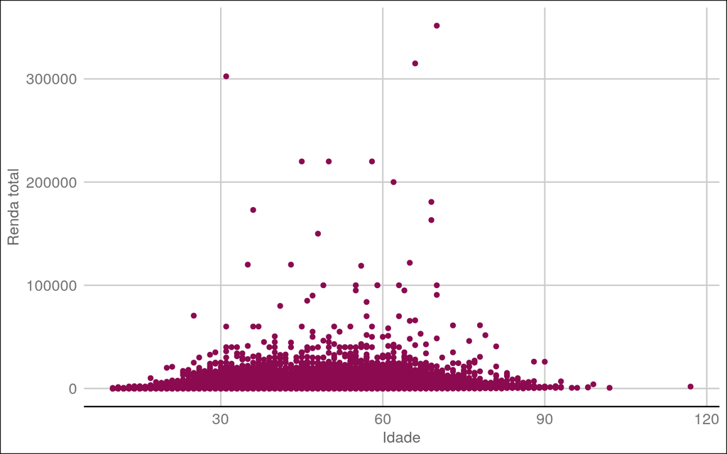

```r
dfna <- na.omit(df)
ggplot(dfna, aes(y=`Renda total`, x=Idade)) + geom_point(color="deeppink4") + theme_gdocs()
```

**OBS:** Observamos que a maioria dos participantes possuem uma renda entre 1000 e 3000 reais

# Analisando renda dos participantes por sexo e idade

## Renda por idade das mulheres

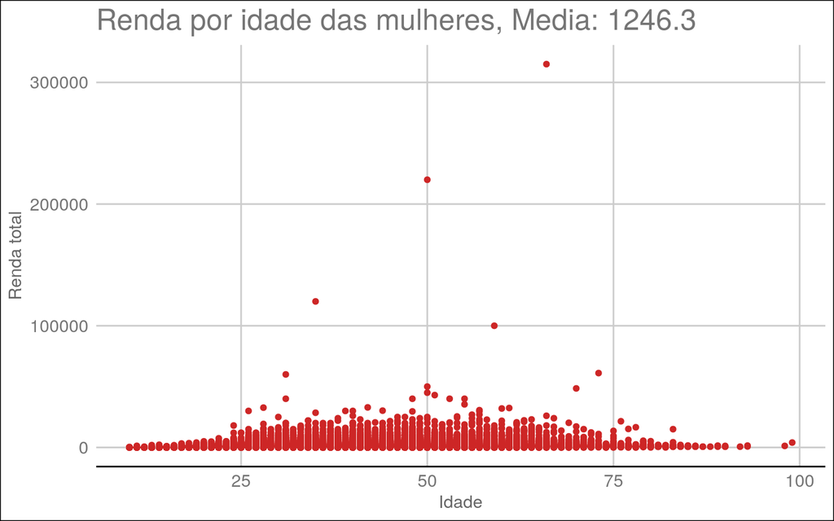

```r
plotF <- ggplot(dfFeminino, aes(y=`Renda total`, x=Idade)) + geom_point(color="firebrick3") + labs(title = str_c("Renda por idade das mulheres, Media: ",round(mean(dfFeminino$`Renda total`),2))) + theme_gdocs()

plotF
```

## Renda por idade dos homens

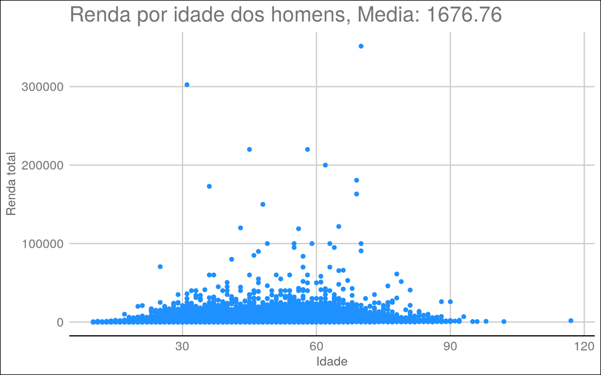

```r
plotM <- ggplot(dfMasculino, aes(y=`Renda total`, x=Idade)) + geom_point(color="dodgerblue") + labs(title = str_c("Renda por idade dos homens, Media: ",round(mean(dfMasculino$`Renda total`),2)))  + theme_gdocs()

plotM
```

**OBS** As Mulheres são mais novas, porém tem uma renda média menor que os homens

# Avaliando a distribuição de renda por cor da pele

```r
dfCorPele <- df %>% na.omit %>% group_by(`Cor da pele`) %>% summarise("Media Salarial"=mean(`Renda total`)) %>% arrange(desc("Media Salarial"))
dfCorPele %>% knitr::kable()
```

| Cor da pele | Media Salarial |
| --- | --- |
| Amarela | 2924.804 |
| Branca | 1952.032 |
| Indígena | 1023.933 |
| Parda | 1126.107 |
| Preta | 1119.386 |

# Reproduzindo gráfico dos dados acima

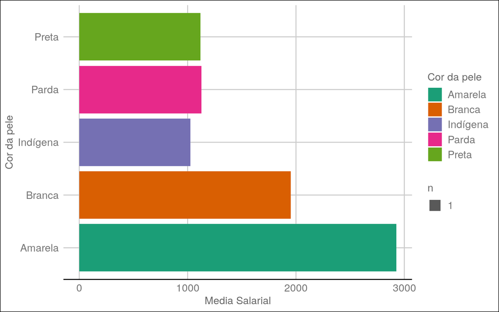

```r
ggplot(dfCorPele, aes(x=`Cor da pele`, y=`Media Salarial`, fill=`Cor da pele`)) + scale_fill_brewer(palette = "Dark2") + geom_bar(stat = "sum") + coord_flip() + theme_gdocs()
```

# Verificando distribuição dos 10 estados com maiores rendas por sexo

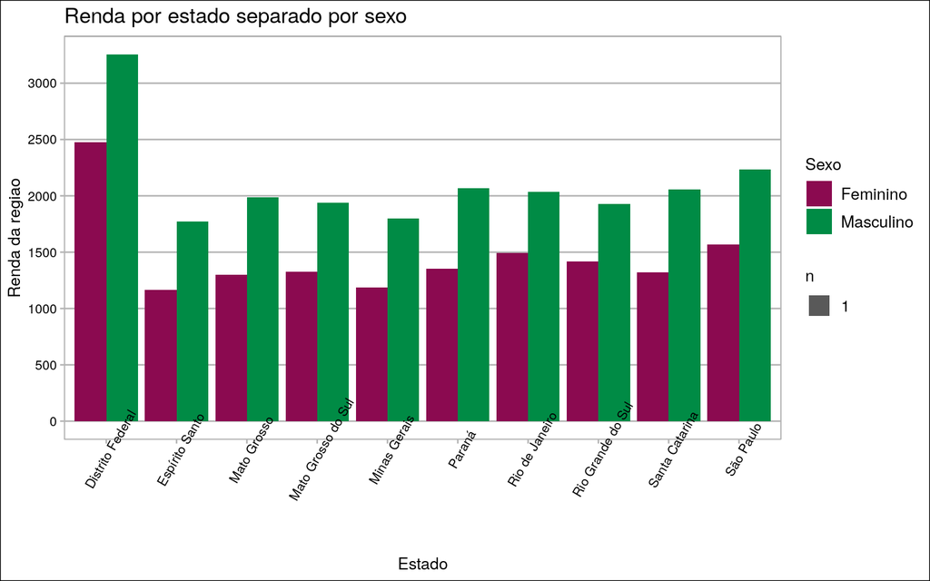

```r
rendaEstado <- df %>% na.omit %>% group_by(Estado, Sexo) %>% summarise("Renda da regiao"=mean(`Renda total`))
maioresRendas <- rendaEstado %>% arrange(desc(`Renda da regiao`)) %>% select(Estado) %>% unique %>% head(10)
estados <- maioresRendas$Estado
rendaUF <- rendaEstado %>% filter(Estado %in% estados)

ggplot(rendaUF, aes(x=Estado, y=`Renda da regiao`, fill=Sexo)) + scale_fill_manual(values = c("deeppink4","springgreen4")) + scale_y_continuous(breaks = seq(0, 5000, 500)) + geom_bar(stat = "sum", position = "dodge") + theme_calc() +
labs(title = "Renda por estado separado por sexo") + theme(axis.text.x = element_text(angle = 60))
```

**OBS:** Nos 10 estados com as maiores rendas naquele ano, os homens tinham o salário mais alto, e o Distrito Federal com a maior renda salarial entre todos.

# Verificando média salarial de cada idade

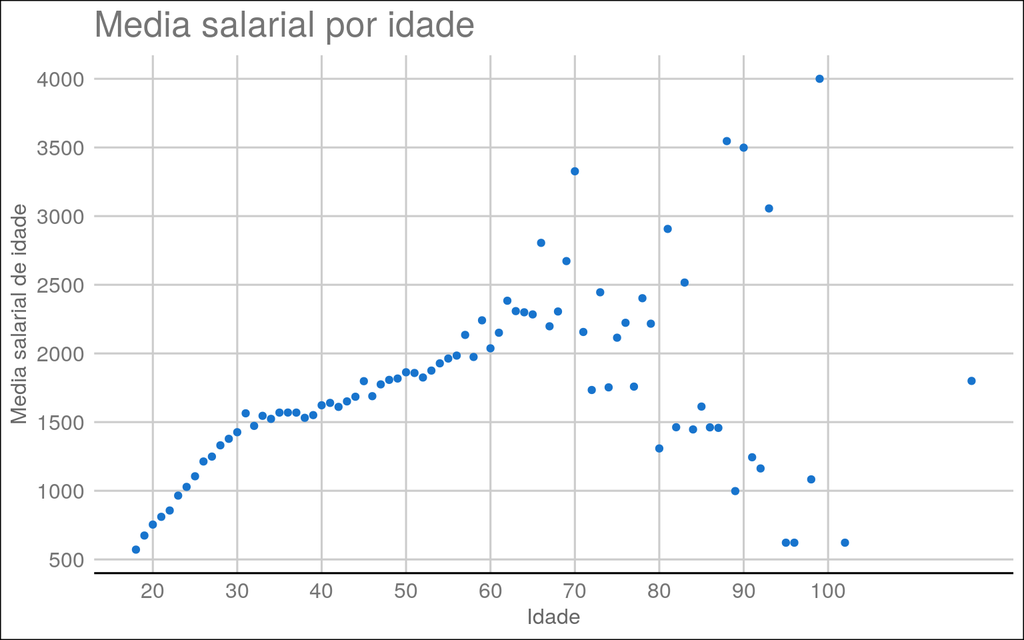

```r
rendaIdade <- df %>% na.omit %>% filter(Idade >= 18 ) %>% group_by(Idade) %>% summarise("Media salarial de idade"=mean(`Renda total`))

ggplot(rendaIdade, aes(x=Idade, y=`Media salarial de idade`)) + geom_point(color="dodgerblue3") +
labs(title = "Media salarial por idade") + scale_x_continuous(breaks = seq(20, 100, 10)) +
scale_y_continuous(breaks = seq(0, 4000, 500)) + theme_gdocs()
```